# Passaic County Technical-Vocational School District — NJ School Data Almanac – NJ District Profiles

NJ School Data Almanac

Passaic County Technical-Vocational School District

PASSAIC COUNTY · TRADITIONAL PUBLIC DISTRICT · no DFG · 4,773 STUDENTS (2026)

4,773

Students

99.7%

4-yr grad rate

5.6%

Chronically absent

$22,277

Per pupil

*9 things the data says about Passaic County Technical-Vocational School District. Every figure is computed from New Jersey Department of Education data via the njschooldata package — nothing is estimated. Comparisons use District Factor Group (DFG) peers.*

No. 1 ENROLLMENT

## Passaic County Tech Grew 42% Since 2015 — and Added 702 Students Straight Through the Pandemic

While most New Jersey districts lost ground after 2019, the county vocational school expanded every year but one, hitting an all-time high of 4,773 students.

Passaic County Technical-Vocational is bigger than it has ever been. Enrollment reached 4,773 students in 2026, the peak of the available record and up 1,417 students, or 42.2%, from 3,356 in 2015.

County vocational schools admit by application and are bounded by building capacity, so this kind of sustained growth signals demand outrunning supply rather than a demographic windfall. The question the enrollment line raises but cannot answer: how much longer can a fixed campus keep absorbing record classes before the waitlist becomes the real story?

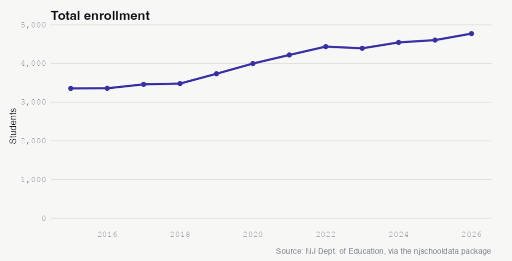

See the underlying data ›

No. 2 ATTENDANCE

## Chronic Absenteeism at PCTVS Fell to 5.6% in 2024 — Less Than Half the Peer Median of 11.4%

After peaking at 10.2% during the post-pandemic slump, absenteeism dropped nearly five points in a single year, landing below even the district’s pre-COVID rate.

Chronic absenteeism — missing roughly a tenth or more of the school year — has lingered across New Jersey since the pandemic. At Passaic County Technical-Vocational, it reversed. The 2024 rate of 5.6% is less than half the peer median of 11.4%, and it sits below even the district’s own pre-pandemic mark of 6.0% in 2019.

The turnaround was abrupt. After a low of 4.2% in 2021 amid disrupted attendance counting, absenteeism climbed to 8.4% in 2022 and peaked at 10.2% in 2023 before falling back to 5.6% in 2024 — a drop of nearly five points in one cycle, erasing the worst of the post-COVID rise.

Strong attendance and a near-universal graduation rate tend to travel together, and at PCTVS they do. The open question is whether the 2024 low holds, or whether absenteeism creeps back as the district absorbs hundreds more students each year.

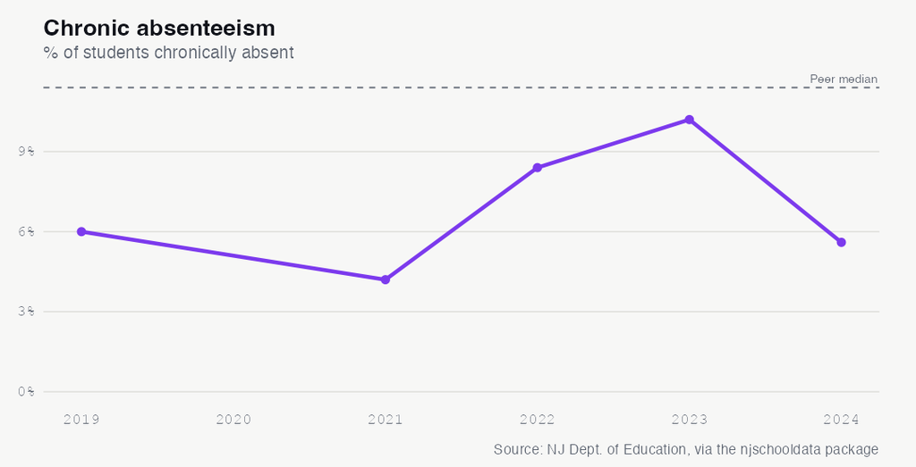

See the underlying data ›

No. 3 DEMOGRAPHICS

## PCTVS’s Black Enrollment Share Was Cut Nearly in Half, From 15.6% to 8.1%, While the White Share Rose to 20.8%

The district stayed majority Hispanic, but its racial composition reshaped sharply over 11 years even as total enrollment hit record highs.

Passaic County Technical-Vocational has long been majority Hispanic, and it still is, with Hispanic students making up 57.9% of enrollment in 2026. But the makeup around that majority has shifted hard. The Black share fell from 15.6% in 2015 to 8.1% in 2026 — a drop of 7.5 percentage points that nearly halved Black representation in the district.

Moving the other direction, the white share climbed from 12.7% to 20.8%, a gain of 8.1 percentage points and the single largest change in the district’s profile. Asian enrollment rose steadily from 8.8% to 11.0%, the multiracial share nearly doubled from 1.2% to 2.1%, and the Hispanic share edged down from 61.6% to 57.9%.

Because this is a county vocational program that admits students by application from across Passaic County, the shift can reflect who applies and who is admitted as much as the county’s underlying population. The data raises a question it cannot resolve: what is driving the steady decline in the Black share precisely as overall enrollment surges to record highs?

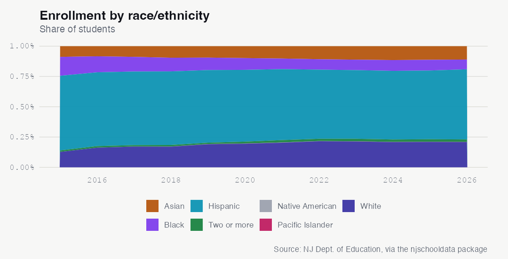

See the underlying data ›

No. 4 GRADUATION

## PCTVS Graduated 99.7% of Its 2025 Class — 98th Percentile Among 616 NJ Peers — as the Cohort Grew to 1,085

Almost no one leaves Passaic County Technical-Vocational without a diploma. The four-year graduation rate reached 99.7% for the class of 2025, placing it in the 98th percentile among 616 New Jersey peer districts and well clear of the peer median of 94.7%.

For a county vocational program blending college-prep academics with career-technical pathways, the consistency suggests the model keeps students enrolled all the way to a diploma. What remains to be seen is whether the district can hold a near-ceiling rate as enrollment keeps climbing toward record highs.

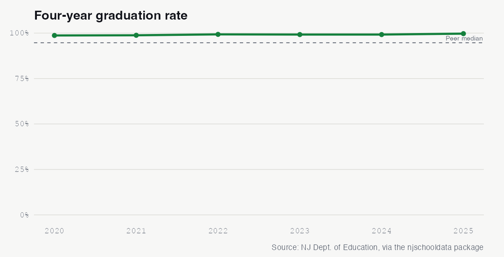

See the underlying data ›

No. 5 COLLEGE READINESS

## Dual Enrollment at PCTVS Surged to 79.1% of Students in 2024, Up From 55.7% in 2018

While AP and IB exam success stayed flat, the share of students earning college credit through dual enrollment climbed by more than 23 points.

Passaic County Technical-Vocational’s college-credit story is being told through dual enrollment, not advanced exams. The share of students taking dual-enrollment coursework rose to 79.1% in 2024, up from 55.7% in 2018 — a gain of more than 23 percentage points that puts roughly four in five students into college-credit classes.

For a vocational district, that route fits — dual enrollment pairs naturally with career-technical pathways and partner colleges. The question is whether this fast-growing pipeline is translating into completed degrees and certifications, a step the participation numbers alone cannot reveal.

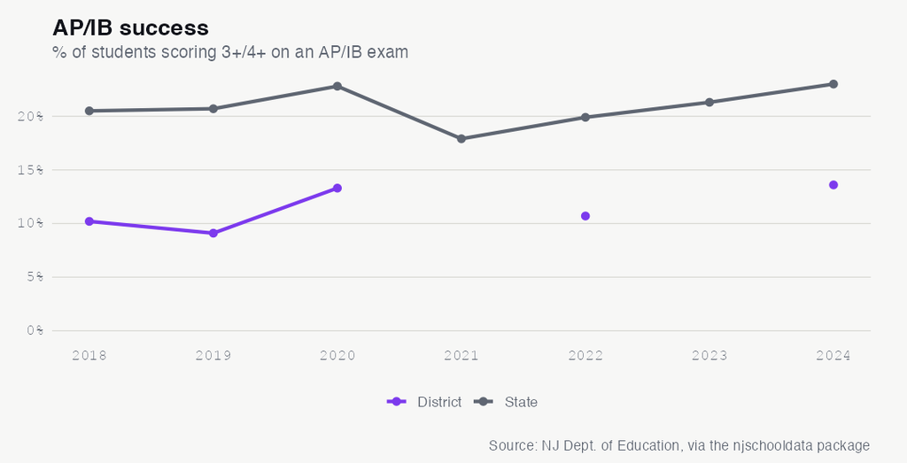

See the underlying data ›

No. 6 FINANCE

## PCTVS Spent $22,277 Per Pupil in 2024 — Up 20% Since 2014 and in the 79th Percentile Among NJ Peers

Per-pupil spending accelerated late even as average daily enrollment grew by more than 1,200 students.

Passaic County Technical-Vocational spent $22,277 per pupil in 2024, placing it in the 79th percentile among New Jersey peer districts and above the peer median of $19,506. That figure is up 20.3% from $18,517 in 2014.

The rise came alongside steady expansion: average daily enrollment grew from 3,274 in 2014 to 4,516 in 2024, so the district was spreading a larger budget across far more students even as the per-pupil number climbed. The sharpest jump landed late, from $20,800 in 2023 to $22,277 in 2024.

The 2025 spending mix tilted toward the classroom, with 53.4% of dollars going to direct instruction, 19.1% to support services, 13.7% to plant operations, and 9.9% to administration. For a vocational program that depends on shops, equipment, and specialized facilities, the question is whether the recent acceleration reflects the rising cost of career-technical instruction or the strain of rapid enrollment growth.

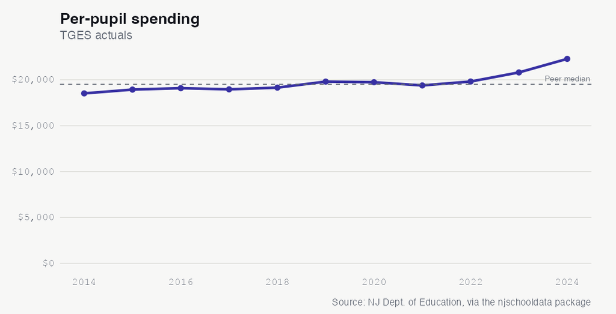

See the underlying data ›

No. 7 EQUITY

## Every PCTVS Graduation Subgroup Cleared 98.2% in 2025, With the Widest Gap Just 1.8 Points

Asian, Hispanic, multilingual-learner, and multiracial students all reached 100%, and economically disadvantaged students hit 99.6%.

Where many districts post wide graduation gaps by race, income, and disability status, Passaic County Technical-Vocational’s class of 2025 stayed tightly bunched near the top. Students who are Asian, Hispanic, multilingual learners, or multiracial all graduated at 100%, and students who are economically disadvantaged reached 99.6% — essentially matching the district total of 99.7%.

Even the lowest reported subgroup rates were strikingly high. Students with disabilities graduated at 98.3% and Black students at 98.2%, leaving the widest gap to the top at just 1.8 percentage points. White students graduated at 99.6% and female students at 99.7%.

In a district where the Black share of enrollment has been shrinking, a near-universal graduation rate for Black students stands out as an asset. The forward question is whether these narrow gaps hold as the senior class continues to grow well past 1,000 students.

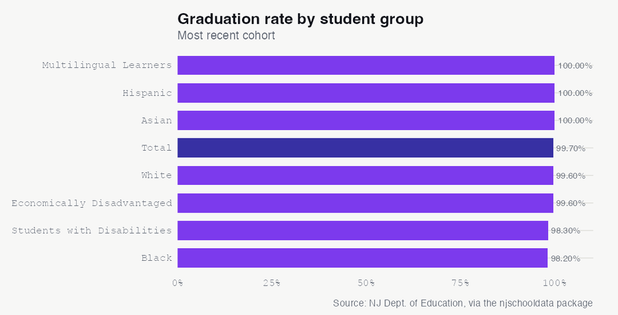

See the underlying data ›

No. 8 ACHIEVEMENT

## NJGPA Math Proficiency at PCTVS Held Near 78% for Three Years — but No ELA Score Is Reported

On the high-school graduation-readiness test, math stayed remarkably stable while the literacy half of the picture is blank.

On New Jersey’s high-school graduation-proficiency assessment, the NJGPA, Passaic County Technical-Vocational students cleared the math bar at 78.0% in 2025. The math rate has been notably steady — 77.8% in 2023, 79.5% in 2024, and 78.0% in 2025 — each year drawn from roughly 1,050 to 1,095 valid test-takers.

The striking part is what’s missing. The district shows no reported ELA proficiency figure for any of the three years; 2023, 2024, and 2025 all come back blank. Whether that reflects a suppression rule, a testing-pathway difference, or a data gap, it leaves the literacy side of the readiness picture invisible.

A steady math proficiency near four in five students is a solid result for a vocational district. But the absent ELA figure raises a basic transparency question: why can families see how PCTVS students perform in math but not in English language arts?

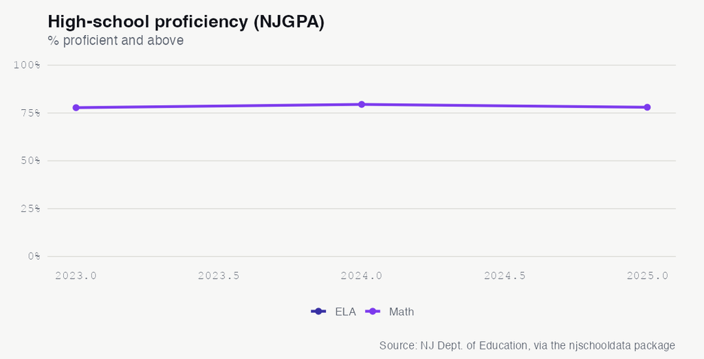

See the underlying data ›

No. 9 DEMOGRAPHICS

## The Share of Economically Disadvantaged Students at PCTVS Climbed to 56.5% in 2026 After Dipping to 46.5% in 2024

The series has lurched throughout, from 50.3% in 2015 up to 68.1% in 2016, back down to 49.8% in 2017, and on from there. That kind of volatility in free- and reduced-lunch counts often tracks changes in how eligibility is certified rather than abrupt shifts in family circumstances, so the figures warrant caution.

What is clearer is the recent direction: after the 2024 dip, the share of students who are economically disadvantaged has climbed two years running, even as total enrollment hit record highs. Whether 56.5% marks a new normal or another swing in a jumpy series is the question next year’s count will answer.

See the underlying data ›

## The Almanac

The full longitudinal record behind the stories above. Every number a reader can check.

### Enrollment (total)

| year | students | yoy | yoy_pct |
| --- | --- | --- | --- |
| 2015 | 3356 | NA | NA |
| 2016 | 3359 | 3 | 0.1 |
| 2017 | 3461 | 102 | 3 |
| 2018 | 3481 | 20 | 0.6 |
| 2019 | 3735 | 254 | 7.3 |
| 2020 | 3999 | 264 | 7.1 |
| 2021 | 4221 | 222 | 5.6 |
| 2022 | 4437 | 216 | 5.1 |
| 2023 | 4393 | -44 | -1 |
| 2024 | 4545 | 152 | 3.5 |
| 2025 | 4605 | 60 | 1.3 |
| 2026 | 4773 | 168 | 3.6 |

### Demographic share (%) by year

| end_year | white | black | hispanic | asian | native_american | pacific_islander | multiracial |
| --- | --- | --- | --- | --- | --- | --- | --- |
| 2015 | 12.7 | 15.6 | 61.6 | 8.8 | 0 | 0 | 1.2 |
| 2016 | 16.2 | 13.2 | 60.9 | 8.3 | 0 | 0 | 1.3 |
| 2017 | 17.1 | 12.1 | 60.8 | 8.8 | 0 | 0 | 1.2 |
| 2018 | 17.1 | 11.3 | 60.8 | 9.5 | 0 | 0.1 | 1.3 |
| 2019 | 19.1 | 10.3 | 59.9 | 9.4 | 0.1 | 0.1 | 1.2 |
| 2020 | 19.5 | 9.7 | 59.2 | 9.8 | 0.1 | 0.1 | 1.6 |
| 2021 | 20.4 | 8.8 | 58.6 | 10.2 | 0.1 | 0 | 2 |
| 2022 | 21.5 | 8.6 | 57.1 | 10.8 | 0.1 | 0 | 1.9 |
| 2023 | 21.3 | 8.6 | 56.7 | 11.1 | 0 | 0.1 | 2.1 |
| 2024 | 20.8 | 8.9 | 56.7 | 11.5 | 0 | 0.1 | 2 |
| 2025 | 21 | 8.9 | 56.7 | 11.2 | 0 | 0.1 | 2.1 |
| 2026 | 20.8 | 8.1 | 57.9 | 11 | 0 | 0.1 | 2.1 |

### Special populations (LEP, FRL)

| end_year | subgroup | students | pct |
| --- | --- | --- | --- |
| 2015 | lep | 30 | 0.9 |
| 2015 | free_reduced_lunch | 1689 | 50.3 |
| 2016 | lep | 18 | 0.5 |
| 2016 | free_reduced_lunch | 2287 | 68.1 |
| 2017 | lep | 10 | 0.3 |
| 2017 | free_reduced_lunch | 1723 | 49.8 |
| 2018 | lep | 20 | 0.6 |
| 2018 | free_reduced_lunch | 2275 | 65.4 |
| 2019 | lep | 13 | 0.3 |
| 2019 | free_reduced_lunch | 2299 | 61.6 |
| 2020 | lep | 8 | 0.2 |
| 2020 | free_reduced_lunch | 2367 | 59.2 |
| 2021 | lep | 30 | 0.7 |
| 2021 | free_reduced_lunch | 2271 | 53.8 |
| 2022 | lep | 22 | 0.5 |
| 2022 | free_reduced_lunch | 2485 | 56.0 |
| 2023 | lep | 22 | 0.5 |
| 2023 | free_reduced_lunch | 2337 | 53.2 |
| 2024 | lep | 32 | 0.7 |
| 2024 | free_reduced_lunch | 2113 | 46.5 |
| 2025 | lep | 32 | 0.7 |
| 2025 | free_reduced_lunch | 2574 | 55.9 |
| 2026 | lep | 43 | 0.9 |
| 2026 | free_reduced_lunch | 2697 | 56.5 |

### Graduation rate 4yr (total)

| year | grad_rate | cohort |
| --- | --- | --- |
| 2020 | 98.7 | 829 |
| 2021 | 98.8 | 833 |
| 2022 | 99.3 | 1072 |
| 2023 | 99.2 | 1039 |
| 2024 | 99.2 | 1047 |
| 2025 | 99.7 | 1085 |

### Graduation by subgroup (2025)

| subgroup | grad_rate | cohort |
| --- | --- | --- |
| asian | 100.0 | 134 |
| hispanic | 100.0 | 584 |
| multilingual learners | 100.0 | 10 |
| multiracial | 100.0 | 17 |
| male | 99.8 | NA |
| total | 99.7 | 1085 |
| female | 99.7 | 612 |
| economically disadvantaged | 99.6 | 765 |
| white | 99.6 | 240 |
| students with disabilities | 98.3 | 117 |
| black | 98.2 | 110 |
| american indian | NA | NA |
| migrant students | NA | NA |
| military-connected students | NA | NA |
| non-binary/undesignated gender | NA | NA |
| students experiencing homelessness | NA | NA |
| students in foster care | NA | NA |

### NJGPA high-school proficiency (% proficient+)

| year | test | prof_above | valid |
| --- | --- | --- | --- |
| 2023 | ela | NA | NA |
| 2023 | math | 77.8 | 1050 |
| 2024 | ela | NA | NA |
| 2024 | math | 79.5 | 1095 |
| 2025 | ela | NA | NA |
| 2025 | math | 78.0 | 1075 |

### Chronic absenteeism (% chronically absent)

| year | chronic_pct |
| --- | --- |
| 2019 | 6 |
| 2021 | 4.2 |
| 2022 | 8.4 |
| 2023 | 10.2 |
| 2024 | 5.6 |

### Disciplinary removals

[output not shown]

### Police notifications (incident counts)

| year | violence | weapons | vandalism | substances | hib | other |
| --- | --- | --- | --- | --- | --- | --- |
| 2019 | 3 | 2 | 0 | 0 | 0 | 0 |
| 2020 | 3 | 1 | 0 | 1 | 0 | 0 |
| 2021 | 0 | 0 | 0 | 2 | 0 | 0 |
| 2022 | 0 | 0 | 0 | 1 | 3 | 0 |
| 2023 | 2 | 0 | 0 | 2 | 0 | 0 |
| 2024 | 1 | 0 | 0 | 0 | 0 | 1 |

### HIB (harassment/intimidation/bullying) investigations

| end_year | alleged | confirmed |
| --- | --- | --- |
| 2019 | 32 | 32 |
| 2020 | 26 | 35 |
| 2021 | 5 | 9 |
| 2022 | 31 | 37 |
| 2023 | 25 | 42 |
| 2024 | 24 | 35 |

### SAT participation (% of grade)

| year | sat_part | state_sat |
| --- | --- | --- |
| 2018 | 83.4 | 72.2 |
| 2019 | 79.2 | 72.1 |
| 2020 | 80.9 | 71.1 |
| 2021 | 31.9 | 45.4 |
| 2022 | 59.4 | 60.8 |
| 2023 | 55.4 | 61.9 |
| 2024 | 63 | 62.7 |

### AP/IB & dual enrollment (% of students)

| year | apib_coursework | apib_exam | ap3_ib4 | state_ap3_ib4 | dual |
| --- | --- | --- | --- | --- | --- |
| 2018 | 13.6 | 14.2 | 10.2 | 20.5 | 55.7 |
| 2019 | 16.1 | 17.3 | 9.1 | 20.7 | 66.1 |
| 2020 | 19.3 | 19.5 | 13.3 | 22.8 | 66.5 |
| 2021 | 15.1 | 16 | NA | 17.9 | 63 |
| 2022 | 16.5 | 17.9 | 10.7 | 19.9 | 60.7 |
| 2023 | 17.4 | 15.2 | NA | 21.3 | 73 |
| 2024 | 17.1 | 17.3 | 13.6 | 23 | 79.1 |

### Special education (raw rows; inspect for classification rate)

| end_year | district_id |
| --- | --- |
| 2024 | 3995 |

### Per-pupil spending (TGES actuals)

| year | per_pupil | rank | ade |
| --- | --- | --- | --- |
| 2014 | 18517 | 16 | 3274 |
| 2015 | 18933 | 16 | 3332 |
| 2016 | 19087 | 16 | 3331 |
| 2017 | 18959 | 15 | 3439 |
| 2018 | 19144 | 17 | 3461 |
| 2019 | 19802 | 16 | 3707 |
| 2020 | 19734 | 18 | 3963 |
| 2021 | 19385 | 17 | 4191 |
| 2022 | 19810 | 16 | 4361 |
| 2023 | 20800 | 16 | 4357 |
| 2024 | 22277 | 17 | 4516 |

### Spending composition shares (2025)

| classroom_share | support_services_share | administration_share | plant_ops_share | food_service_share | extracurricular_share | equipment_share |
| --- | --- | --- | --- | --- | --- | --- |
| 53.4 | 19.1 | 9.9 | 13.7 | NA | 3.8 | 0.7 |

### Staffing ratios

| end_year | student_teacher_district | student_admin_district | student_counselor_district | student_nurse_district |
| --- | --- | --- | --- | --- |
| 2024 | 12:1 | 146:1 | 238:1 | 452:1 |

Back to top